# Credit Card Default Prediction Analysis

Yash Gupta

2025-04-11

# **1. Introduction**

This report presents an individual analysis of the widely-used credit card client dataset, which contains information on users’ demographics, credit history, and payment behavior. The main goal of the task is to develop predictive models that can identify clients who are likely to default on their credit card payments in the upcoming month.

To achieve this, I apply both logistic regression and random forest classifiers—focusing not just on prediction accuracy but also on interpretability. Special attention is given to feature engineering and evaluation metrics to ensure the models are both effective and explainable.

This kind of analysis is highly relevant in real-world financial settings, where understanding default risk helps institutions minimize losses and make better lending decisions.

**Workflow for The Analysis :**

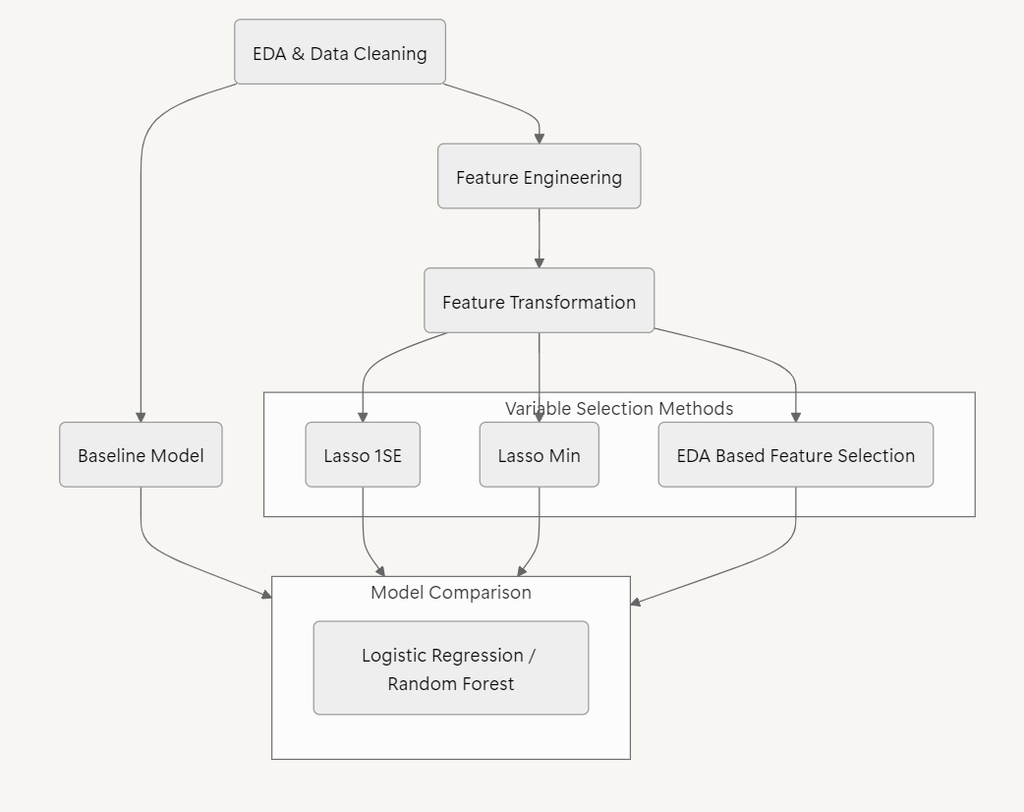

# **2. Data Description: Default of Credit Card Clients**

**Observations**: 30,000 credit card clients  
**Time Period**: April 2005 to September 2005  
**Target Variable**:  
- `customer_default`: Binary (1 = default, 0 = no default)

**Predictor Variables**:

#### **1. Demographic & Credit Info**

- `limit_bal`: Credit limit (NT dollar)
- `sex`: Gender (1 = male, 2 = female)
- `education`: Education level (1 = grad school, 2 = university, 3 = high school, 4 = others)
- `marriage`: Marital status (1 = married, 2 = single, 3 = others)
- `age`: Age (years)

#### **2. Payment History (Past 6 Months)**

- `pay_1` to `pay_6`: Repayment status for September 2005 (`pay_1`) to April 2005 (`pay_6`)
  - **Scale**:
    - `-1` = Pay duly
    - `0` = No consumption
    - `1` = 1-month delay, …, `9` = 9+ months delay

#### **3. Bill Statements (NT dollar)**

- `bill_amt1` to `bill_amt6`: Bill amount for September 2005 (`bill_amt1`) to April 2005 (`bill_amt6`)

#### **4. Payment Amounts (NT dollar)**

- `pay_amt1` to `pay_amt6`: Amount paid in September 2005 (`pay_amt1`) to April 2005 (`pay_amt6`)

### **Key Notes**:

1. **Time Alignment**:
   - `pay_1`/`bill_amt1`/`pay_amt1` = September 2005 (most recent)
   - `pay_6`/`bill_amt6`/`pay_amt6` = April 2005 (oldest)
2. **Class Imbalance**:
   - Default rate ≈ 22% (minority class).

# **3. Data Cleaning and EDA**

## **Train-Test Split**

First of all we separate out 20% of the data as test_data.csv for final testing. We performed all the analysis including EDA or train_data.csv. While doing so, we corrected one mislabeled feature `pay_0` to `pay_1`.

- There are total 23 predictors and one response (`default`). [1] “limit_bal” “sex” “education” “marriage” “age” “pay_1”  
  [7] “pay_2” “pay_3” “pay_4” “pay_5” “pay_6” “bill_amt1” [13] “bill_amt2” “bill_amt3” “bill_amt4” “bill_amt5” “bill_amt6” “pay_amt1” [19] “pay_amt2” “pay_amt3” “pay_amt4” “pay_amt5” “pay_amt6” “default”
- For simplicity let’s call pay_1 to pay_6 as `pay_vars`, bill_amt1 to bill_amt6 as `bill_amt_vars` and pay_amt1 to pay_amt6 `pay_amt_vars`.

## **Exploratory Data Analysis**

### **`default` Proportion**

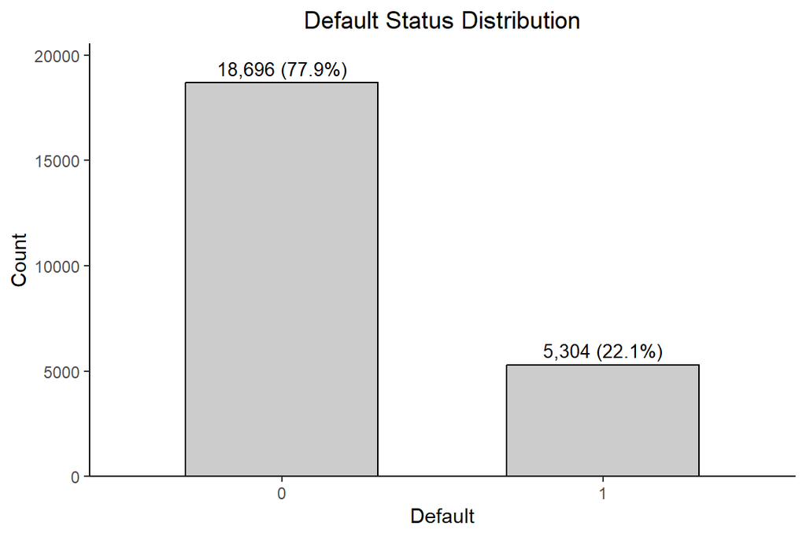

### **`sex`, `marriage` and `education` Proportion**

```r
for (col in c('sex', 'marriage', 'education')) {
  counts <- table(df[[col]])
  props <- round(prop.table(counts) * 100, 2)

  result <- data.frame(
    Category = names(counts),
    Count = as.numeric(counts),
    Proportion = paste0(props, "%")
  )

  cat("\n--- Distribution of", toupper(col), "---\n")
  print(knitr::kable(result, align = c('l', 'r', 'r')))
  cat("\n")
}
```

— Distribution of SEX —

| Category | Count | Proportion |
| --- | --- | --- |
| 1 | 9508 | 39.62% |
| 2 | 14492 | 60.38% |

— Distribution of MARRIAGE —

| Category | Count | Proportion |
| --- | --- | --- |
| 0 | 39 | 0.16% |
| 1 | 10941 | 45.59% |
| 2 | 12754 | 53.14% |
| 3 | 266 | 1.11% |

— Distribution of EDUCATION —

| Category | Count | Proportion |
| --- | --- | --- |
| 0 | 11 | 0.05% |
| 1 | 8409 | 35.04% |
| 2 | 11245 | 46.85% |
| 3 | 3958 | 16.49% |
| 4 | 104 | 0.43% |
| 5 | 228 | 0.95% |
| 6 | 45 | 0.19% |

**Comments:**

- We will rename all the categories for better readability.
- Looking at proportion of category “0” in *MARRIAGE* which has no meaning in data description, it’s better to merge it with “Others” i.e. “3”.
- We will combine 0,5,6,.. with 4 in distribution of EDUCATION.

#### **Merging small categories and Renaming them**

```r
# Cleaning and renaming categories
df <- df %>%
  mutate(
    # Renaming SEX (1 = Male, 2 = Female)
    sex = factor(sex, levels = c(1, 2), labels = c("male", "female")),

    # Cleaning MARRIAGE (merge 0 into 3 as "Others")
    marriage = case_when(
      marriage %in% c(0, 3) ~ "others",
      marriage == 1 ~ "married",
      marriage == 2 ~ "single",
      TRUE ~ "others"
    ),

    # Cleaning EDUCATION (merge 0,4,5,6 into "others")
    education = case_when(
      education == 1 ~ "grad School",
      education == 2 ~ "university",
      education == 3 ~ "high School",
      education %in% c(0, 4, 5, 6) ~ "others",
      TRUE ~ "others"
    )
  )

# Verifying the new distributions
for (col in c('sex', 'marriage', 'education')) {
  counts <- table(df[[col]])
  props <- round(prop.table(counts) * 100, 2)

  result <- data.frame(
    Category = names(counts),
    Count = as.numeric(counts),
    Proportion = paste0(props, "%")
  )

  cat("\n--- Cleaned Distribution of", toupper(col), "---\n")
  print(knitr::kable(result, align = c('l', 'r', 'r')))
  cat("\n")
}
```

— Cleaned Distribution of SEX —

| Category | Count | Proportion |
| --- | --- | --- |
| male | 9508 | 39.62% |
| female | 14492 | 60.38% |

— Cleaned Distribution of MARRIAGE —

| Category | Count | Proportion |
| --- | --- | --- |
| married | 10941 | 45.59% |
| others | 305 | 1.27% |
| single | 12754 | 53.14% |

— Cleaned Distribution of EDUCATION —

| Category | Count | Proportion |
| --- | --- | --- |
| grad School | 8409 | 35.04% |
| high School | 3958 | 16.49% |
| others | 388 | 1.62% |
| university | 11245 | 46.85% |

#### **Default Rate vs Demographic Predictors:**

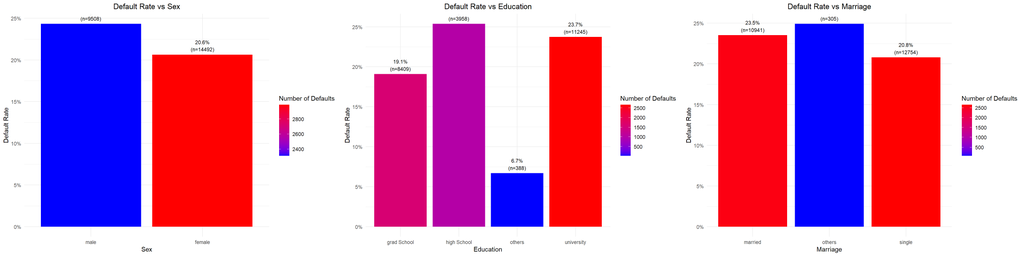

### Exploring `pay_1`,`pay_2`,`pay_3`,`pay_4`,`pay_5`,`pay_6` variables

```
##
## ==================================================
## Payment Status Analysis: pay_1
## ==================================================
## Status        Count Proportion   Defaults Default Rate
## --------------------------------------------------
## -2            2,181       9.1%        287        13.2%
## -1            4,556      19.0%        771        16.9%
## 0            11,814      49.2%      1,508        12.8%
## 1             2,924      12.2%        988        33.8%
## 2             2,139       8.9%      1,470        68.7%
## 3               269       1.1%        207        77.0%
## 4                61       0.3%         42        68.9%
## 5                22       0.1%         10        45.5%
## 6                11       0.0%          6        54.5%
## 7                 8       0.0%          6        75.0%
## 8                15       0.1%          9        60.0%
```

**Comments**:

- Since, there is no interpretation of -2 in data description, I researched about the data description on internet and this is what I found :
- -2: No consumption; -1: Paid in full; 0: The use of revolving credit; 1 = payment delay for one month; 2 = payment delay for two months; . . .; 8 = payment delay for eight months; 9 = payment delay for nine months and above.
- Also there is not much difference in the default rate for class “-1”, “-2” and “0” for all pay_vars. We can safely merge them.
- We do not have good number observations for 6,7,8,… . Which can effect the performance of model due to class volume. It should be better if we merge them too, so that we can have good number of observations to build model on.
- We can clearly observe that there is positive correlation in default rate and payment status value.

```r
for (pay_var in paste0("pay_", 1:6)) {
  df[[pay_var]] <- ifelse(df[[pay_var]] < 0, 0,
                          ifelse(df[[pay_var]] > 6, 6, df[[pay_var]]))

}
```

### **Default Rate by Payment Status for Each `pay_vars`**

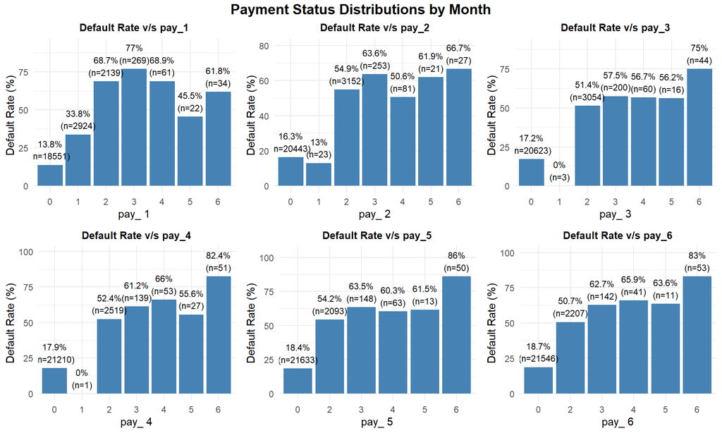

### **Scatter Plot Explanation**

**Observing the Default rate for Continuous Variables**

### **Exploring `bill_amt1`, `bill_amt2`, `bill_amt3`, `bill_amt4`, `bill_amt5`, `bill_amt6`**

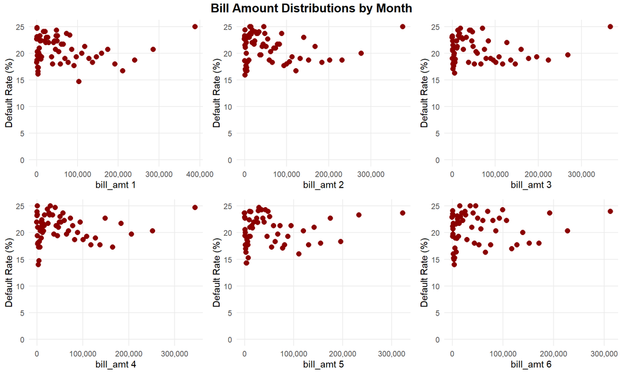

### **Exploring `pay_amt1`, `pay_amt2`, `pay_amt3`, `pay_amt4`, `pay_amt5`, `pay_amt6`**

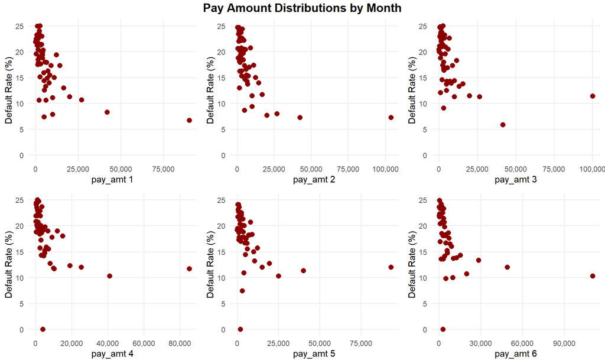

```r
bill_plots <- list()

for (i in 1:6) {
  var <- paste0("pay_amt", i)
  bill_plots[[i]] <- auto_plot(df,var,'default',0.0125) +
    labs(x = paste("pay_amt", i)) +
    theme(plot.title = element_text(size = 10))
}

# Arrange the plots in a 3x2 grid
grid.arrange(
  grobs = bill_plots,
  nrow = 2,
  ncol = 3,
  top = textGrob("Pay Amount Distributions by Month", gp = gpar(fontsize = 14, fontface = "bold"))
)
```

**Comments**

- From the above plots, we can clearly observe that pay_amt and default rate has -ve correlation.
- However, this variable is as welll highly right skewed. Do deal with it we need to adopt robust methods while creating logistic regression model.
- We can see there is an highly influential as well as high leverage point in each plot, which indicates that appox 5% (1200) observations are high leverage and that is enough for a regression line to drag towards them. We must need to truncate these influential observations.
- In order to do that, we can truncate these 5% observations to the 95% percentile value.

```r
# Enhanced Truncation Function with Verification
truncate_top_outliers <- function(data, var_name, percentile = 0.95) {

  # Calculate cutoff
  trunc_value <- quantile(data[[var_name]], probs = percentile, na.rm = TRUE)

  # Create new column name
  new_col <- paste0(var_name, "_truncated")

  # Apply truncation
  data <- data %>%
    mutate(
      "{new_col}" := ifelse(
        .data[[var_name]] > trunc_value,
        trunc_value,
        .data[[var_name]]
      )
    )

  return(data)
}


vars_to_truncate <- paste0("pay_amt", 1:6)
for (var in vars_to_truncate) {
  df <- truncate_top_outliers(df, var)
}
```

### **After Truncation of 5% Right Most Observations**

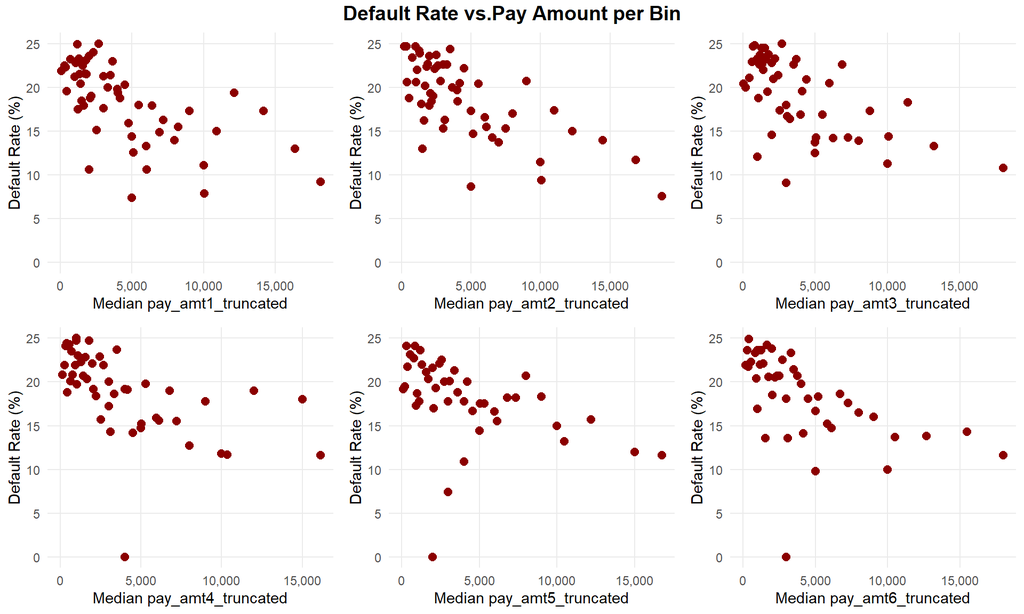

```r
# Generate analysis data for all bill_amt variables
plot_list <- lapply(paste0("pay_amt", 1:6,"_truncated"), function(var) {
  # Get analysis data
  df_analysis <- analyze_equal_sample(var,'default',df,0.0125)

  # Convert formatted strings to numeric
  df_plot <- df_analysis %>%
    mutate(
      median_amount = as.numeric(gsub(",", "", median)),
      default_rate = as.numeric(gsub("%", "", default_rate))
    )

  # Create plot
  ggplot(df_plot, aes(x = median_amount, y = default_rate)) +
    geom_point(size = 2.5, color = "darkred") +
    labs(
      x =  paste("Median", var),
      y = "Default Rate (%)"
    ) +
    theme_minimal() +
    theme(
      plot.title = element_text(size = 11, face = "bold"),
      panel.grid.minor = element_blank()
    ) +
    scale_x_continuous(labels = scales::comma) +
    scale_y_continuous(limits = c(0, 25))  # Adjust based on your data
})

# Arrange plots in 2x3 grid
grid.arrange(
  grobs = plot_list,
  nrow = 2,
  ncol = 3,
  top = textGrob("Default Rate vs.Pay Amount per Bin",
               gp = gpar(fontsize = 14, fontface = "bold")) )
```

### **Limit Balance vs Default Rate**

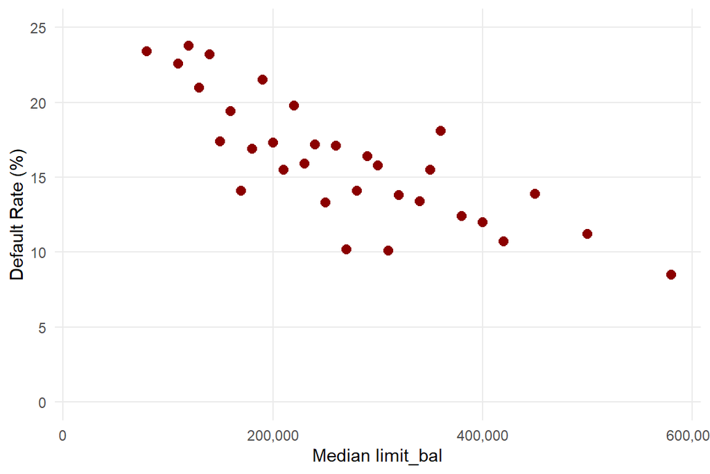

```r
auto_plot(df,"limit_bal",'default',0.0125)
```

**Comments:** Limit Balance have good linear relationship with Default Rate.

### **Default Rate vs Age Group**

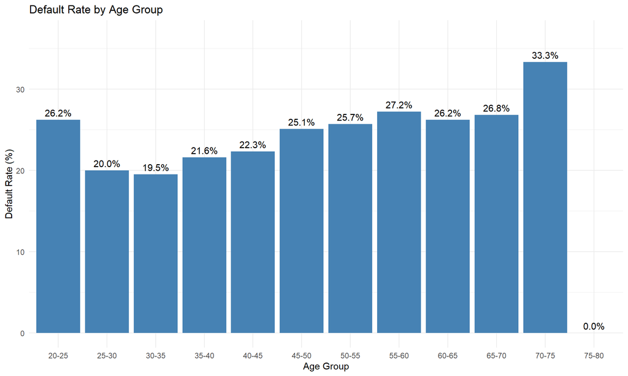

**Comments:** It seems from the bar plot that age also have some impact Default rate.

# **4. Feature Engineering (Using Domain Knowledge)**

Please Click on show code to see new features and their definition :

#### **1. VARIABLES_DENOTING_THE_WORST_PAYMENT_STATUS_IN_LAST_N_MONTH**

```r
payment_history <- df[, paste0("pay_", 1:6)]

# Function to get worst status in last n months
get_worst_status <- function(n) {
  apply(payment_history[, 1:n, drop = FALSE], 1, max)
}

# Creating new variables for n in c(1,2,3,6) months
for (n in c(1,2,3,6)) {
  df[[paste0("worst_status_", n, "m")]] <- get_worst_status(n)
}
```

#### **2. VARIABLES_DENOTING_IF_PAYMENT_STATUS_GE_1_2_3_OR_5_IN_LAST_1_2_3_OR_6_MONTHS**

```r
# Function to check if any status >= x in last n months
status_ge_x <- function(x, n) {
  apply(payment_history[, 1:n, drop = FALSE], 1, function(row) any(row > x))
}

# Creating variables for combinations of x in c(0,1,2) and n in c(1,2,3,6)
for (x in c(0,1,2,3,5)) {
  for (n in c(1,2,3,6)) {
    df[[paste0("status_ge", x, "_last", n, "m")]] <- as.numeric(status_ge_x(x, n))
  }
}
```

#### **3. COUNT_OF_MONTHS_WITH_DELAYED_PAYMENTS (STATUS >= x)**

```r
for (x in c(0,1,2,3,5)) {
  df[[paste0("count_months_ge_", x)]] <- rowSums(df[, paste0("pay_", 1:6)] >= x)
}
```

#### **4. MONTHS_SINCE_LAST_DELINQUENCY (STATUS >= x)**

```r
for (x in c(0,1,2,3,5)) {
  df[[paste0("months_since_delq_ge_", x)]] <- apply(df[, paste0("pay_", 1:6)], 1, function(row) {
    idx <- which(row >= x)
    ifelse(length(idx) > 0, min(idx), 0)
  })
}

## IF IN LAST 6 MONTHS ONE HAS NEVER DELINQUENT (STATUS >= X)

for (x in c(0,1,2,3,5)) {
  df[[paste0("last6m_never_delq_ge_", x)]] <- apply(df[, paste0("pay_", 1:6)], 1, function(row) {
    idx <- which(row >= x)
    ifelse(length(idx) > 0, 0, 1)
  })
}
```

#### **5. AVERAGE BILL AMOUNT CALCULATION**

```r
df$avg_bill_3m <- rowMeans(df[, paste0("bill_amt", 1:3)])
df$avg_bill_6m <- rowMeans(df[, paste0("bill_amt", 1:6)])
```

#### **6. MAXIMUM_BILL_AMOUNT_CALCULATION**

```r
df$max_bill_1m <- df$bill_amt1
df$max_bill_3m <- apply(df[, paste0("bill_amt", 1:3)], 1, max)
df$max_bill_6m <- apply(df[, paste0("bill_amt", 1:6)], 1, max)
```

#### **7. MINIMUM_BILL_AMOUNT_CALCULATION**

```r
df$min_bill_3m <- apply(df[, paste0("bill_amt", 1:3)], 1, min)
df$min_bill_6m <- apply(df[, paste0("bill_amt", 1:6)], 1, min)
```

#### **8. CREATING_CREDIT_UTILIZATION_MATRIX**

```r
util_matrix <- as.matrix(df[, paste0("bill_amt", 1:6)]) / df$limit_bal
colnames(util_matrix) <- c("Sep_util", "Aug_util", "Jul_util", "Jun_util", "May_util", "Apr_util")
```

```r
# Average utilization
df$avg_util_3m <- rowMeans(util_matrix[, 1:3])
df$avg_util_6m <- rowMeans(util_matrix[, 1:6])

# Maximum utilization
df$max_util_1m <- util_matrix[, 1]
df$max_util_3m <- apply(util_matrix[, 1:3], 1, max)
df$max_util_6m <- apply(util_matrix[, 1:6], 1, max)

# Minimum utilization
df$min_util_3m <- apply(util_matrix[, 1:3], 1, min)
df$min_util_6m <- apply(util_matrix[, 1:6], 1, min)
```

#### **10. UTILIZATION_VOLATILITY**

```r
# Months with utilization > threshold
df$months_util_gt_90 <- rowSums(util_matrix > 0.9)
df$months_util_gt_75 <- rowSums(util_matrix > 0.75)
df$months_util_gt_60 <- rowSums(util_matrix > 0.6)
df$months_util_gt_50 <- rowSums(util_matrix > 0.5)

# Months with utilization < threshold
df$months_util_lt_25 <- rowSums(util_matrix < 0.25)
df$months_util_lt_10 <- rowSums(util_matrix < 0.1)

# Utilization volatility
df$util_volatility_6m <- apply(util_matrix, 1, sd)
```

#### **11. MORE UTILIZATION RELATED VARIABLES**

```r
  ## refers to the number of months since utilization fell below 25%
  df$months_since_util_lt_25 <- apply(util_matrix, 1, function(x) {
    ifelse(length(which(x < 0.25)) == 0,0,which(x < 0.25)[1])
  })

  ## checks if utilization never dropped below 25% in the last 6 months.
  df$last6m_never_util_lt_25 <- apply(util_matrix, 1, function(x) {
    length(which(x < 0.25)) == 0
  })

  ## refers to the number of months since utilization fell below 10%.
  df$months_since_util_lt_10 <- apply(util_matrix, 1, function(x) {
    ifelse(length(which(x < 0.10)) == 0,0,which(x < 0.10)[1])
  })

  ## checks if utilization never dropped below 10% in the last 6 months.
  df$last6m_never_util_lt_10 <- apply(util_matrix, 1, function(x) {
    length(which(x < 0.10)) == 0
  })

  ## refers to the number of months since utilization exceeded 90%
  df$months_since_util_gt_90 <- apply(util_matrix, 1, function(x) {
    ifelse(length(which(x > 0.9)) == 0, 0, which(x > 0.9)[1])
  })

  ## checks if utilization never exceeded 90% in the last 6 months.
  df$last6m_never_util_gt_90 <- apply(util_matrix, 1, function(x) {
    length(which(x > 0.9)) == 0
  })

  ## refers to the number of months since utilization exceeded 75%.
  df$months_since_util_gt_75 <- apply(util_matrix, 1, function(x) {
    ifelse(length(which(x > 0.75)) == 0, 0, which(x > 0.75)[1])
  })

  ## checks if utilization never exceeded 75% in the last 6 months.
  df$last6m_never_util_gt_75 <- apply(util_matrix, 1, function(x) {
    length(which(x > 0.75)) == 0
  })
```

#### **12. CALCULATION OF MONTHLY PAYMENT PROPORTIONS (PAYMENT AMOUNT / BILL AMOUNT)**

```r
  ## Convert the 'pay_amt' and 'bill_amt' columns to matrices for calculations
  payments <- as.matrix(df[, paste0("pay_amt", 1:6)])
  bills <- as.matrix(df[, paste0("bill_amt", 1:6)])

  ## Calculate the proportion of payments made by dividing payments by bills
  prop_paid_matrix <- payments / bills

  ## Handle Inf or NaN values by replacing them with 0
  prop_paid_matrix[is.infinite(prop_paid_matrix) | is.nan(prop_paid_matrix)] <- 0

  ## Set the column names to represent payment percentages for each month
  colnames(prop_paid_matrix) <- c("Sep_paid_pct", "Aug_paid_pct", "Jul_paid_pct", "Jun_paid_pct", "May_paid_pct", "Apr_paid_pct")
```

#### **13. CALCULATION OF PAYMENT BEHAVIOR METRICS (FULL PAYMENT, LOW PAYMENT, OVERPAYMENT etc.)**

```r
  ## Average proportion paid (last 3m/6m)
  df$avg_paid_pct_3m <- rowMeans(prop_paid_matrix[, 1:3], na.rm = TRUE)  # Sep-Aug-Jul
  df$avg_paid_pct_6m <- rowMeans(prop_paid_matrix[, 1:6], na.rm = TRUE)  # Sep-Apr

  ## Months with full payment (100%)
  df$months_full_payment <- rowSums(prop_paid_matrix == 1, na.rm = TRUE)

  ## Months with minimal payment (<30%)
  df$months_low_payment <- rowSums(prop_paid_matrix < 0.3, na.rm = TRUE)

  ## Months with overpayment (>100%)
  df$months_overpayment <- rowSums(prop_paid_matrix > 1, na.rm = TRUE)

  ## Worst Payment Ratio
  df$min_paid_pct_6m <- apply(prop_paid_matrix, 1, function(x) {
    if (all(is.na(x))) NA else min(x, na.rm = TRUE)
  })
```

#### **14. MORE VARIABLES FOR PAYMENT BEHAVIOR**

```r
  ## Payment volatility (standard deviation)
  df$paid_pct_volatility <- apply(prop_paid_matrix, 1, sd, na.rm = TRUE)

  ## Current payment ratio (most recent month)
  df$current_paid_pct <- prop_paid_matrix[, 1]

  ## Months since last underpayment (<90%)
  df$months_since_underpayment <- apply(prop_paid_matrix, 1, function(x) {
    ifelse(length(which(x < 0.9)) == 0,0,which(x < 0.9)[1]) })

  ## Never Underpaid in last 6 months
  df$last6m_never_underpayment <- apply(prop_paid_matrix, 1, function(x) {
    length(which(x < 0.9)) == 0 })

  ## Ever missed payment (0% paid)
  df$ever_missed_payment <- as.numeric(rowSums(prop_paid_matrix == 0, na.rm = TRUE) > 0)
```

## **FEATURE EXPLORER**

FEATURE EXPLORER

# **5. Feature Transformation (Modification of New Features)**

*Assessing the Good and Bad Variables and Creating Final Set of Features Before Modeling*

- We have more than hundred of features now, but we need to consider only those that have some explanatory power.
- For each variable I observed their relationship with default rate through the scatter plot, and based on the relationship I applied some transformation on the predictor so that, the relationship between Default Rate and predictor is roughly linear. The predictor which shows no relationship has been dropped later and the predictors with good linear relationship after the transformation has been kept.
- Following code chunk contains all the modification and transformation in the features, that has been done. You can follow feature explorer to understand why I called some variables bad and transformed the others.

```r
# Transformation
CleanTransformation <- function(df){

  # ============================================================================
  # 1. Transformation of Variables related to pay_amt
  # ============================================================================
  for (n in c(3,6)) {
    v <- paste0("avg_pay_amt_",n,"m")
    df[[paste0("log_",v)]] <- ifelse(df[[v]]>=1000,log(df[[v]]),log(1000))
    df[[paste0("pt_log_",v)]] <- ifelse(df[[v]]>=1000,log(df[[v]])**(-2),log(1000)**(-2))
    df[[paste0(v,"_lt_1000")]] <- ifelse(df[[v]]<1000,1,0)
  }

  for (n in c(3,6)) {
    v <- paste0("max_pay_amt_",n,"m")
    df[[paste0("log_",v)]] <- ifelse(df[[v]]>=2500,log(df[[v]]),2500)
    df[[paste0("pt_log_",v)]] <- ifelse(df[[v]]>=2500,log(df[[v]])**(-3),log(2500)**(-3))
    df[[paste0(v,"_lt_2500")]] <- ifelse(df[[v]]<2500,1,0)
  }

  for (n in c(3,6)) {
    v <- paste0("min_pay_amt_",n,"m")
    df[[paste0(v,"_eq_0")]] <- ifelse(df[[v]]==0,1,0)
  }

  # ============================================================================
  # 2. Transformation of Variables related to utilization
  # ============================================================================

  for (n in c(3,6)) {
    v <- paste0("avg_util_",n,"m")
    df[[paste0("floored_",v)]] <- ifelse(df[[v]]>=0.025,df[[v]],0.025)
    df[[paste0(v,"_lt_2.5")]] <-  ifelse(df[[v]]<0.025,1,0)
  }

  for (n in c(3,6)) {
    v <- paste0("max_util_",n,"m")
    df[[paste0("floored_",v)]] <- ifelse(df[[v]]>=0.025,df[[v]],0.025)
    df[[paste0(v,"_lt_2.5")]] <-  ifelse(df[[v]]<0.025,1,0)
  }

  for (n in c(3,6)) {
    v <- paste0("min_util_",n,"m")
    df[[paste0("pt_",v)]] <- ifelse(df[[v]]>=0.025,df[[v]]**0.5,0.025**0.5)
    df[[paste0(v,"_eq_0")]] <-  ifelse(df[[v]]==0,1,0)
    df[[paste0(v,"_lt_0")]] <-  ifelse(df[[v]]<0,1,0)
  }

  # ============================================================================
  # 3. Transformation of Limit Balance
  # ============================================================================

  df[["log_limit_bal"]] <- ifelse(df$limit_bal>=0,log(df$limit_bal),log(1000))

  # ============================================================================
  # 4. Transformation of Variables Based on Worst_status
  # ============================================================================

  for (n in c(1,3,6)) {
    v <- paste0("worst_status_",n,"m")
    df[[paste0(v,"_ge_2")]] <-  ifelse(df[[v]]>=2,1,0)
    df[[paste0(v,"_le_0")]] <-  ifelse(df[[v]]<=0,1,0)
  }

  # ============================================================================
  # 5. Transformation of Age, Education, Sex, Marriage
  # ============================================================================

  v <- "age"
  df[[paste0(v,"_le_25")]]  <-  ifelse(df[[v]]<=25,1,0)
  df[[paste0(v,"_gt_45")]]  <-  ifelse(df[[v]]>45,1,0)

  v<- "education"
  df[[paste0(v,"_others")]] <- ifelse(df[[v]]=="others",1,0)
  df[[paste0(v,"_grad")]]   <- ifelse(df[[v]]=="grad School",1,0)

  v<- "sex"
  df[["sex_male"]]          <- ifelse(df[[v]]=="male",1,0)

  v<- "marriage"
  df[["if_married"]]        <- ifelse(df[[v]]=="married",1,0)

  # ============================================================================
  # 6. Transformation of Variables Based on Count of Months wiht Status >= x
  # ============================================================================

  for (n in c(3,5)) {
    v <- paste0("count_months_ge_",n)
    df[[paste0(v,"_eq_0")]] <-  ifelse(df[[v]]==0,1,0)
  }

  # ============================================================================
  # 6. Transformation of Variables Based on Count of Months wiht Status >= x
  # ============================================================================

  for (n in c(1,3)) {
    v <- paste0("months_since_delq_ge_",n)
    df[[paste0(v,"_eq_0")]] <-  ifelse(df[[v]]==0,1,0)
  }

  for (n in c(2,5)) {
    v <- paste0("months_since_delq_ge_",n)
    df[[paste0(v,"_eq_1")]] <-  ifelse(df[[v]]==1,1,0)
  }

  #  df[["floored_months_since_delq_ge_1"]] <- ifelse(df$months_since_delq_ge_1>=1,
  #                                                   df$months_since_delq_ge_1,1)

  # ============================================================================
  # 7. Transformation of Variables Based on Months with utilization lt/gt x%
  # ============================================================================

  for (n in c(10,25)) {
    v <- paste0("months_util_lt_",n)
    df[[paste0(v,"_eq_0")]] <-  ifelse(df[[v]]==0,1,0)
    df[[paste0(v,"_eq_6")]] <-  ifelse(df[[v]]==6,1,0)
  }

  for (n in c(50)) {
    v <- paste0("months_util_gt_",n)
    df[[paste0(v,"_eq_0")]] <-  ifelse(df[[v]]==0,1,0)
  }

  v <- "util_volatility_6m"
  df[[paste0(v,"eq_0")]]    <-  ifelse(df[[v]]==0,1,0)

  v<- "util_coeff_variation_6m"
  df[[paste0(v,"ge_150")]]  <- ifelse(df$util_coeff_variation_6m>=150,1,0)
  df[[paste0("pt_",v)]]     <- ifelse(df$util_coeff_variation_6m<150,df$util_coeff_variation_6m**0.5,150**0.5)

  # ============================================================================
  # 8. Transformation of Variables Based on paid_pct (actually proportion)
  # ============================================================================

  for (n in c(3,6)) {
    v <- paste0("avg_paid_pct_",n,"m")
    df[[paste0(v,"_le_0")]]   <-  ifelse(df[[v]]<=0,1,0)
    df[[paste0(v,"_ge_0.5")]] <-  ifelse(df[[v]]>=0.5,1,0)
    #    df[[paste0("log_",v)]]    <-  ifelse(df[[v]]<=0.5,ifelse(df[[v]]>0,log(df[[v]]),-4),0.5)
  }

  v<- "months_overpayment"
  df[[paste0("capped_5_",v)]] <-  ifelse(df[[v]]<=5,df[[v]],5)


  return(df)

}
```

## **Example of Some New Features and Transformations**

### **Worst Payment Status In Last 6 Months : worst_status_6m**

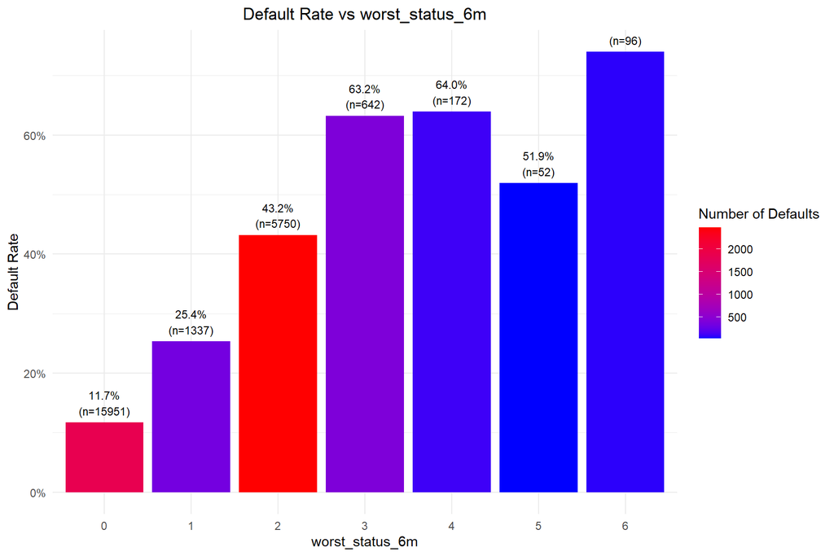

### **Average Pay Amount**

- **Before Transformation**:

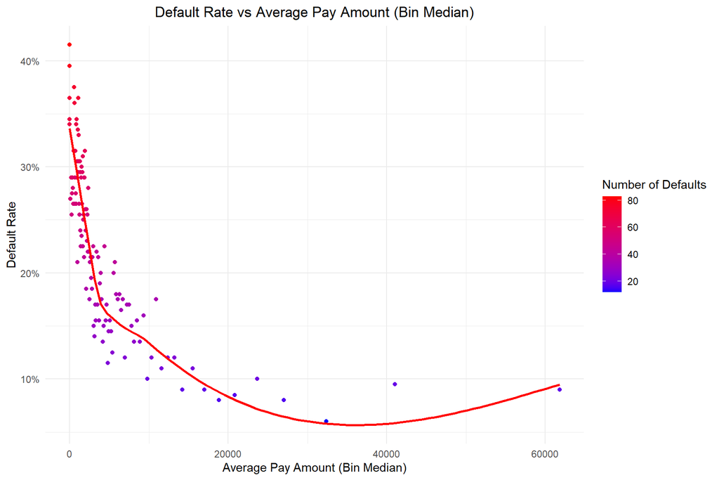

- **After Transformation (< $1000) & (>= $1000)**

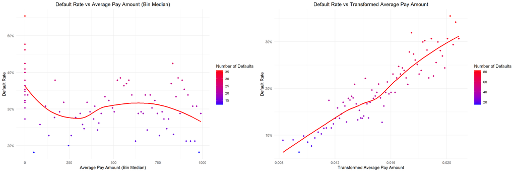

- I have saved Pre-processing, Feature Engineering and Transformation functions in separate files for ease of computation. **This is Final Step before Variable selection.**

```r
df <- read_csv("Data/train_data.csv", col_names = TRUE, show_col_types = FALSE )
df <- df |> wrangle_data() |> FE() |> CleanTransformation()
```

*Now, we are finally done with the Data Cleaning, Exploratory Data Analysis and Feature Engineering.*

# **6. Logistic Regression**

## **Baseline Model**

I performed the following steps to build the initial logistic regression model based on the transformed dataset.

- **Normalized training data** using computed scaling factors.
- **Trained logistic regression** model on normalized features.
- **Performed stratified 5-fold cross-validation** to evaluate thresholds.
- **Tuned threshold** for best F1, Precision, Recall, Accuracy, and balance.
- **Preprocessed and normalized test data** using training parameters.
- **Predicted on test set** using the trained model and optimal threshold.
- **Evaluated model** using confusion matrix, ROC AUC, and PR AUC.
- **Plotted ROC and PR curves** for visual performance analysis.

```r
df          <- read_csv("Data/train_data.csv", col_names = TRUE, show_col_types = FALSE )
train_data        <- wrangle_data(df)
processed_train   <- FE(train_data)
Transformed_train <- CleanTransformation(processed_train)
modelling_data    <- Transformed_train[, !(names(Transformed_train) %in% unlist(drop_list))]

# Normalization
norm_factors      <- normalizing_factors(modelling_data)
normalized_train  <- normalized_data(modelling_data,norm_factors)

#-------------------------------------------------------------------------------

# Logistic Regression
logit_model <- glm(default ~ ., data = normalized_train, family = binomial)

#-------------------------------------------------------------------------------
# Stratified 5-fold Cross Validaition for deciding optimal threshold
#-------------------------------------------------------------------------------

folds <- createFolds(normalized_train$default, k = 5)
thresholds <- seq(0.01, 0.99, by = 0.04)

metrics_list <- vector("list", length(thresholds))

for(i in seq_along(thresholds)) {

  threshold_metrics <- list(Precision = numeric(5),Recall = numeric(5),
                            F1 = numeric(5),Accuracy = numeric(5)       )

  for(fold in seq_along(folds)) {
    cv_train <- normalized_train[-folds[[fold]], ]
    cv_valid <- normalized_train[folds[[fold]], ]

    cv_model <- glm(default ~ ., data = cv_train, family = binomial)

    # Prediction on validation fold
    cv_probs <- predict(cv_model, newdata = cv_valid, type = "response")
    cv_preds <- ifelse(cv_probs >= thresholds[i], 1, 0)

    pred_factor <- factor(cv_preds, levels = c(0, 1))
    true_factor <- factor(cv_valid$default, levels = c(0, 1))

    cm          <- caret::confusionMatrix(pred_factor, true_factor, positive = "1")

    # Storing all metrics
    threshold_metrics$Precision[fold] <- cm$byClass["Precision"]
    threshold_metrics$Recall[fold] <- cm$byClass["Recall"]
    threshold_metrics$F1[fold] <- cm$byClass["F1"]
    threshold_metrics$Accuracy[fold] <- cm$overall["Accuracy"]

  }

  # metrics across folds
  metrics_list[[i]] <- list(
    Threshold = thresholds[i],
    Precision = mean(threshold_metrics$Precision, na.rm = TRUE),
    Recall = mean(threshold_metrics$Recall, na.rm = TRUE),
    F1 = mean(threshold_metrics$F1, na.rm = TRUE),
    Accuracy = mean(threshold_metrics$Accuracy, na.rm = TRUE)
  )
  print(paste0(i*100/length(thresholds),"% Done"))
}

metrics_df <- do.call(rbind, lapply(metrics_list, as.data.frame))
optimal_thresholds <- list(
  Max_F1 = metrics_df$Threshold[which.max(metrics_df$F1)],
  Max_Precision = metrics_df$Threshold[which.max(metrics_df$Precision)],
  Max_Recall = metrics_df$Threshold[which.max(metrics_df$Recall)],
  Balanced = metrics_df$Threshold[which.min(abs(metrics_df$Precision - metrics_df$Recall))],
  Max_Accuracy = metrics_df$Threshold[which.max(metrics_df$Accuracy)]
)

#-------------------------------------------------------------------------------
# Prediction on Test Set
#-------------------------------------------------------------------------------
df               <- read_csv("Data/test_data.csv", col_names = TRUE, show_col_types = FALSE )
test_data        <- wrangle_data(df)
processed_test   <- FE(test_data)
Transformed_test <- CleanTransformation(processed_test)
prediction_data  <- Transformed_test[, !(names(Transformed_test) %in% unlist(drop_list))]

# Normalization with Normalization Factors obtained from training data
normalized_test  <- normalized_data(prediction_data,norm_factors)
#-------------------------------------------------------------------------------


test_probs <- predict(logit_model, newdata = normalized_test, type = "response")
test_preds <- ifelse(test_probs >= optimal_thresholds$Max_F1, 1, 0)

# Confusion matrix metrics
pred_factor <- factor(test_preds, levels = c(0, 1))
true_factor <- factor(normalized_test$default, levels = c(0, 1))
cm          <- caret::confusionMatrix(pred_factor, true_factor, positive = "1")

# ROC and PR curves
roc_obj <- pROC::roc(normalized_test$default, test_probs)
pr_obj <- pr.curve(scores.class0 = test_probs,
                   weights.class0 = as.numeric(normalized_test$default == 1),curve=T)

# Compiling results
results <- data.frame(
  AUC_ROC = roc_obj$auc,
  AUC_PR = pr_obj$auc.integral,
  Precision = cm$byClass["Precision"],
  Recall = cm$byClass["Recall"],
  F1_Score = cm$byClass["F1"],
  Accuracy = cm$overall["Accuracy"],
  Optimal_Threshold = optimal_thresholds$Max_F1
)

print(results)

## Ploting curves
par(mfrow = c(1,2))
plot(roc_obj, main = "ROC Curve")
plot(pr_obj, main = "PR Curve")
```

### **Model Evaluation at Optimal Threshold**

The **optimal threshold** corresponding to the **maximum F1-score** was found to be **0.29**. At this threshold, the model achieved the following performance metrics on the test set:

| Metric | Value |
| --- | --- |
| Precision | 0.5270 |
| Recall | 0.5571 |
| F1 Score | 0.5415 |
| Accuracy | 0.7916 |

**ROC-AUC and PR-AUC Curve**

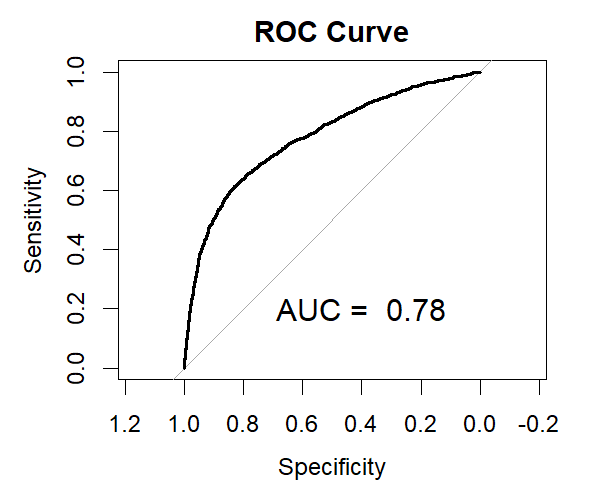

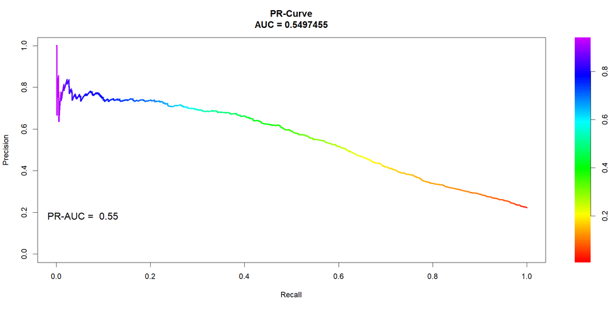

## **LASSO Logistic Regression**

**Steps**:

```r
#-------------------------------------------------------------------------------
# LASSO REGRESSION
#-------------------------------------------------------------------------------
library(glmnet)
# Converting data to matrix format (required by glmnet)
x_train <- model.matrix(default ~ ., normalized_train)[, -1]  # Removes intercept column
y_train <- normalized_train$default

lasso_cv <- cv.glmnet(x = x_train,
                      y = y_train,
                      family = "binomial",
                      alpha = 1,  # 1 for Lasso, 0 for Ridge
                      type.measure = "auc",
                      nfolds = 5)


# Lambda that gives maximum AUC
best_lambda <- lasso_cv$lambda.min

# Or most regularized model within 1SE of max AUC (simpler model)
lambda_1se <- lasso_cv$lambda.1se


x_test <- model.matrix(default ~ ., normalized_test)[, -1]
y_test <- normalized_test$default


# Predict probabilities
test_probs <- predict(lasso_cv,
                      newx = x_test,
                      s = lambda_1se,
                      type = "response",
                      exact = TRUE,
                      x=x_train,
                      y=y_train)[, 1]


test_preds <- ifelse(test_probs >= optimal_thresholds$Max_F1, 1, 0)

# Confusion matrix metrics
pred_factor <- factor(test_preds, levels = c(0, 1))
true_factor <- factor(normalized_test$default, levels = c(0, 1))
cm          <- caret::confusionMatrix(pred_factor, true_factor, positive = "1")

# ROC and PR curves
roc_obj <- pROC::roc(normalized_test$default, test_probs)
pr_obj <- pr.curve(scores.class0 = test_probs,
                   weights.class0 = as.numeric(normalized_test$default == 1),curve=T)

# Compiling results
results <- data.frame(
  AUC_ROC = roc_obj$auc,
  AUC_PR = pr_obj$auc.integral,
  Precision = cm$byClass["Precision"],
  Recall = cm$byClass["Recall"],
  F1_Score = cm$byClass["F1"],
  Accuracy = cm$overall["Accuracy"],
  Optimal_Threshold = optimal_thresholds$Max_F1
)

print(results)

## Plot curves
par(mfrow = c(1,2))
plot(roc_obj, main = "ROC Curve")
plot(pr_obj, main = "PR Curve")

#-------------------------------------------------------------------------------
# AUC_ROC    AUC_PR Precision    Recall  F1_Score  Accuracy Optimal_Threshold
# Precision 0.7767925 0.5517946 0.5103093 0.5945946 0.5492372 0.7833333 0.25
#-------------------------------------------------------------------------------
```

### **Results**

#### **Lambda Evaluation For Lasso**

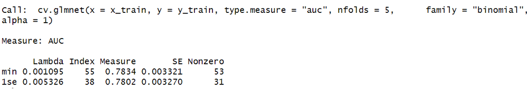

#### **Feature Importance**

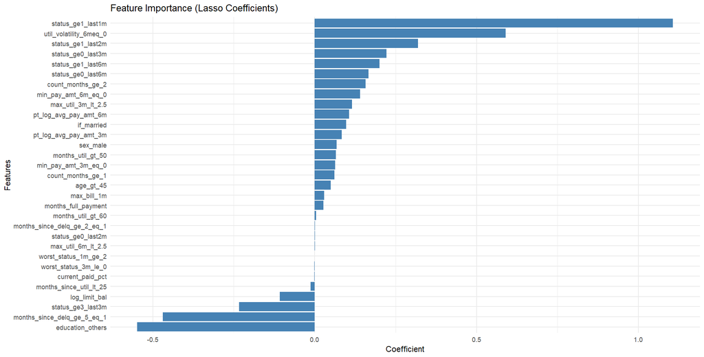

**Comments**

#### **Model Evaluation at Optimal Threshold (lasso 1se)**

| Metric | Value |
| --- | --- |
| AUC (ROC) | 0.7768 |
| AUC (PR) | 0.5518 |
| Precision | 0.5103 |
| Recall | 0.5946 |
| F1 Score | 0.5492 |
| Accuracy | 0.7833 |

**ROC-AUC and PR-AUC Curve**

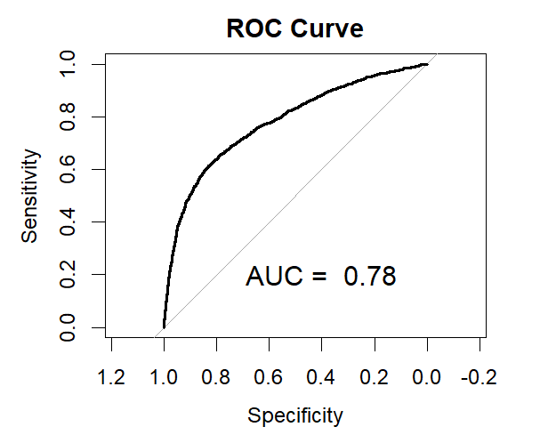

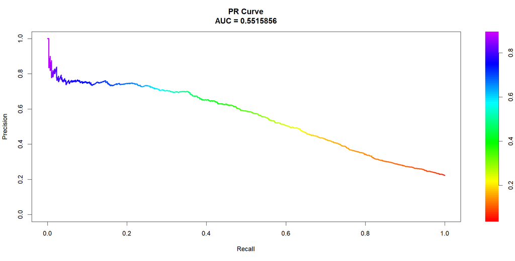

**Comments:** Surprisingly, Baseline Model and LASSO Based Model have approximately same AUC-ROC and PR-Curve.

## **Feature Selection using Stepwise Regression**

- **Full model:** Built using linear regression with all predictors.
- **Hyper-parameters:** Entry p-value (SLE) : 0.05 and Removal p-value (SLS) : 0.05.
- **Feature selection steps:** Predictors are added/removed based on p-values at each step.
- **Plot:** Visual representation of predictor selection and removal during the stepwise process.

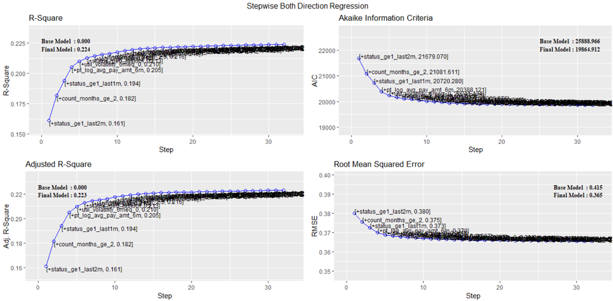

### **Logistic Regression Model Coefficients, Confusion Matrix and Model Performance Metrics**

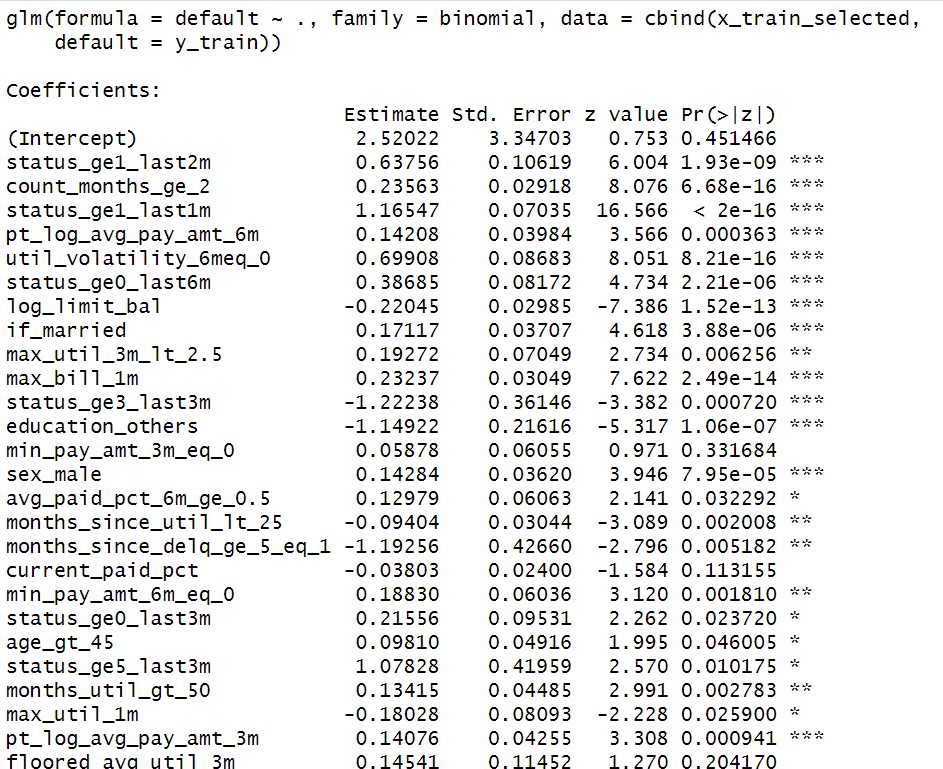

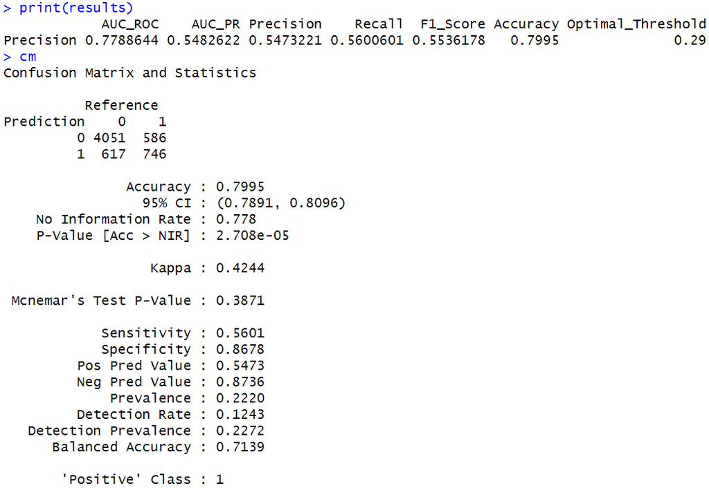

### **Model Comparison**

[output not shown]

# **7. Random Forest**

For Random Forest, I tried many things, tuned it on various class weights and threshold but could not get any better result than what we got through applying Logistic Regression on Stepwise selected Features. Due to time constraint I am not able to do whole analysis of Random Forest as it takes a lot more time for model to run to find the best hyperparameters. However, following the pattern, I found that model performs better when class weights are in 2:1 for positive and negative classes. You can run RFComparison.R to confirm the result.

### **Model Comparison**

This is the Model output when class weights are 2:1 and classification Threshold (p) is 0.5.

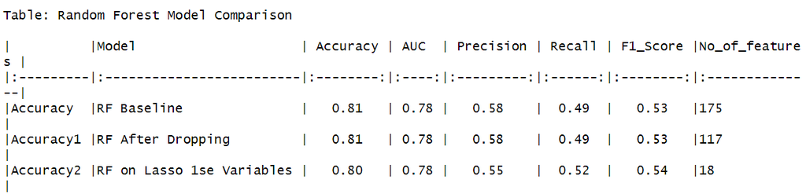

**Random_Forest_Feature_Importance:**

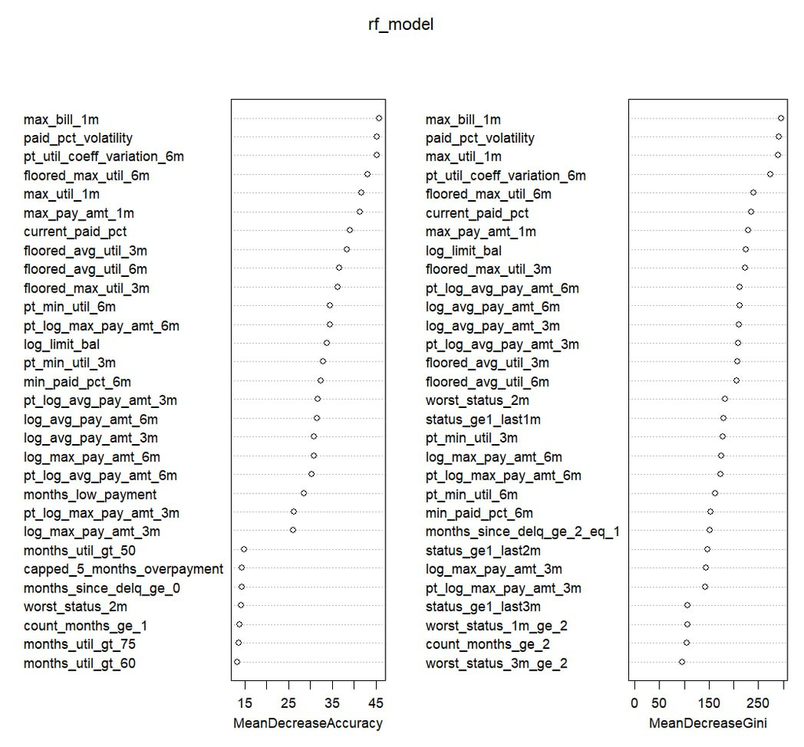

# **Conclusion**

### **Future Work:**

Due to Time Constraint, I was not able to perform these methods:

- **Segmentwise Modelling:** We can segment the training data into low-risk, medium-risk and high-risk segments based on default rate with help of decision tree as shown in the below image. Doing so will result in homogeneous training sets. Segmentwise modelling captures even small patterns while modelling on whole training data captures only the general patterns.

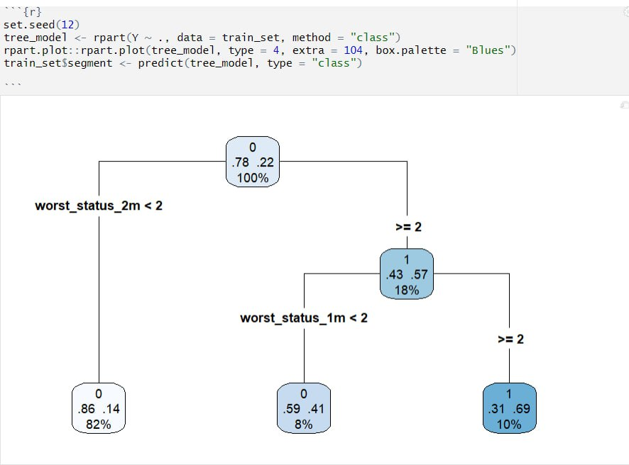

- **Rule-Fit Classifier:** In logistic regression, we have not included the interaction terms. With a motivation of including appropriate interaction terms, we look forward to Rule-Fit Classifier. A Rule Fit Classifier is nothing but a regularized (usually via lasso) Linear Model with original predictors and their interactions. The interactions are obtained using decision trees. An interaction in a rule fit classifier is nothing but the decision rule which is used to get to a certain node of the tree. One can use any tree-based ensemble methods to get these interaction terms.
- **Extensive Grid Search** for hyper-parameter tuning for Random Forest. (Computationally Intensive)